# Projet 3 JobBot - Maxime Castel et Cyprien Lebrun

## Script python de Web Scraping du résultat de recherche d'annonce sur le site de Pôle Emploi.

Bibliothèques

```python
import pandas as pd
from requests import get
from requests.exceptions import RequestException
from contextlib import closing
from bs4 import BeautifulSoup
from sqlalchemy import create_engine, text
import os,configparser
import re
import datetime
```

Configuration du moteur sqlalchemy pour intéragir avec la BDD sous phpmyadmin. Paramétrage de la connection avec login/PW avec un fichier cnf et le module os.configparser Création en code sql de la table qui accueille les données extraites

```python
config = configparser.ConfigParser()
config.read_file(open(os.path.expanduser("~/.datalab.cnf")))
#
#base = args.base
#
myBDD="Job_Bot_Cyprien_Maxime?charset=utf8mb4"
con = create_engine("mysql://%s:%s@%s/%s" % (config['myBDD']['user'], config['myBDD']['password'], config['myBDD']['host'], myBDD))

con.execute("""
CREATE TABLE IF NOT EXISTS `Job_Bot_Cyprien_Maxime`.`AnnoncesPE` (

Reference CHAR(7) NOT NULL,
Intitule VARCHAR(200) NULL DEFAULT NULL,
Employeur VARCHAR(250) NULL DEFAULT NULL,
Localite VARCHAR(250) NULL DEFAULT NULL,
Date_MIEL DATE NOT NULL,
Date_MAJ DATE NOT NULL,
Contrat VARCHAR(200) NULL DEFAULT NULL,
Temps_travail VARCHAR(35) NULL DEFAULT NULL,
Salaire VARCHAR(80) NULL DEFAULT NULL,
Savoirs VARCHAR(1000) NULL DEFAULT NULL,
Savoir_etre VARCHAR(1000) NULL DEFAULT NULL,
Qualification VARCHAR(50) NULL DEFAULT NULL,
Expérience VARCHAR(250) NULL DEFAULT NULL,
Formation VARCHAR(100) NULL DEFAULT NULL,
Secteur_activite VARCHAR(200) NULL DEFAULT NULL,
Lien_partenaire VARCHAR(200) NULL DEFAULT NULL,
Provenance VARCHAR(50) NULL DEFAULT NULL,
Contact VARCHAR(250) NULL DEFAULT NULL,
Description VARCHAR(5000) NULL DEFAULT NULL,
Mots_cles VARCHAR(150) NULL DEFAULT NULL,
PRIMARY KEY (`Reference`))
ENGINE = InnoDB
AUTO_INCREMENT = 0
DEFAULT CHARACTER SET = utf8mb4
COLLATE = utf8mb4_bin;
""")
```

```
<sqlalchemy.engine.result.ResultProxy at 0x7fe4b7a9db00>
```

- Programmation de fonctions pour se connecter à l'URL en vérifiant que la connection est 'saine'. - Message d'erreur en cas de problème de connection. - Récupération des URL des annonces du résultat de recherche.

```python
def simple_get(url):
    """
    Se connecte a l'url, si statut = 200 retourne le contenu ( en appelant is_good_response)
    """
    try:
        with closing(get(url, stream=True)) as resp:
            if is_good_response(resp):
                return resp.content
            else:
                return None

    except RequestException as e:
        log_error('Error during requests to {0} : {1}'.format(url, str(e)))
        return None


def is_good_response(resp):
    """
    Renvoie 200 si connection a l'url
    """
    content_type = resp.headers['Content-Type'].lower()
    return (resp.status_code == 200
            and content_type is not None
            and content_type.find('html') > -1)


def log_error(e):
    """
    retourne l'erreur
    """
    print(e)


def get_url(soup):
    """
    Recupère les urls une par une
    """
    urls = []
    for link in soup.find_all('h2', {'class': 'media-heading'}):
        partial_url = link.a.get('href')
        url = 'https://candidat.pole-emploi.fr' + partial_url
        urls.append(url)
    return urls
```

Critères de recherche : 'python', région Centre ('24R'). Stockage des url dans une liste. Limitation éventuelle du nombre d'offres en phase de développement

```python
html=simple_get('https://candidat.pole-emploi.fr/offres/recherche?lieux=24R&motsCles=python&offresPartenaires=true&range=0-0&rayon=10&tri=0')
soup= BeautifulSoup(html,'html.parser')

def get_nb(soup):
    nb=soup.find("h1").text
    idxnb=nb.index(' offre')
    nb=nb[0:idxnb]
    return int(nb)

listeUrl=[]
dico = {}

url1=0
nbOffre=int(get_nb(soup))

#nbOffre=20
```

Première boucle récupérant les URL une par une

```python
while(url1<=nbOffre):


    url2 = url1+149 if (url1+150<nbOffre) else nbOffre
    urlR="%d-%d" % (url1, url2)

    url='https://candidat.pole-emploi.fr/offres/recherche?lieux=24R&motsCles=python&offresPartenaires=true&range='+urlR+'&rayon=10&tri=0'
    url=simple_get(url)

    soup=BeautifulSoup(url, 'html.parser')
    allUrl=get_url(soup)
    url1+=150
```

Boucle principale de récupération des infos sur chaque URL des annonces, en fonction des besoins définis en amont. cf. le fichier calc des besoins et du dictionnaire des entités de la table.

```python
     for x in allUrl:


        liste=[]

        raw_html = simple_get(x)
        soup = BeautifulSoup(raw_html, 'html.parser')

        title = soup.find("h1").text

        date = soup.find("span", itemprop={"datePosted"}).text

        try:
            secteur = soup.find("span", itemprop={"industry"}).text
        except:
            secteur=''

        address = soup.find("span", itemprop={"name"}).text
        description = soup.find("div", itemprop={"description"}).text

        skills = str(soup.find_all("span", itemprop={"skills"}))
        skills = skills.replace('class="skill-name" itemprop="skills">','').replace('<span','').replace("<span","").replace("</span>","")


        xp = soup.find("span", itemprop={"experienceRequirements"}).text

        contrat = soup.find("dd").text

        try:
            statut = soup.find("span", itemprop={"qualifications"}).text
        except:
            statut = ""

        entreprise = str(soup.find_all('h4', {"class":"t4 title"})[0:1])
        entreprise = entreprise[22:len(entreprise)].replace("</h4>]","").replace("\n","")



        salaire = str(soup.find_all("span", itemprop={"baseSalary"}))

        try:
            idS1=salaire.index('itemprop="unitText"')
            salaire=salaire[idS1:len(salaire)]
            idS1=salaire.index('content=')
            salaire=salaire[idS1:len(salaire)].replace('content="',"")
            if (salaire.find("minValue"))>=0:
                idS2=salaire.index('" itemprop="maxValue"')
                salaire=salaire[0:idS2].replace('" itemprop="minValue"></span><span ',' - ')
            else:
                idS2=salaire.index('"')
                salaire=salaire[0:idS2]

        except:
            salaire=""


        partenaire = str(soup.find("a", {"id": "idLienPartenaire"}))

        try:
            idx=partenaire.index("href=")
            idP=partenaire.index("id=")
            idO1=partenaire.index("alt=")
            idO2=partenaire.index("src=")
            origin=partenaire[idO1+30:idO2-2]
            partenaire = partenaire[idx:idP].replace('href="','').replace('"','')

        except:
            partenaire=""
            origin=""
        ref = str(soup.find_all("span", itemprop={"value"})[0:1])
        ref=ref[24:len(ref)].replace("</span>]","")



        try:
            formation = soup.find('span', itemprop={"educationRequirements"}).text

        except:
            formation=""

        try:
            savetre = soup.find('h4',class_='t6 skill-subtitle', string='Savoir-être professionnels').next_sibling

            savoir_etre=""

            savoir_etre_pro=[]

            for i in  savetre.find_all("span", class_="skill-name"):

                savoir_etre= i.text

                savoir_etre_pro.append(savoir_etre)

        except:
            ref
            savoir_etre_pro=[]

        try:
            temps_job = soup.find("dd", itemprop={"workHours"}).text
            #print(temps_job)
        except:
            temps_job = ""

        try:

            mailto=re.compile("mailto", re.IGNORECASE)
            mail_contact = soup.find("a", href={mailto},class_="",shape="rect").text
            #print(mail_contact)
        except :
            mail_contact =""

        try:

            contact_nom = soup.find("div", class_="apply-block").find("dd").text
            #print(contact_nom)

        except:

            contact_nom =""

        contact = contact_nom+mail_contact
        print(contact)


         listeCol=[title,date,secteur,address,salaire,description,skills,xp,contrat,temps_job,statut,entreprise,partenaire,origin,formation,str(savoir_etre_pro),temps_job,contact]
        motclef=""
        z=0
        for a in listeCol:

            """
            Paramétrage d'une boucle pour recupérer les mots-clefs et les ajouter('append') à la liste.
             """
            liste.append(a)
            a=a.lower()

            if ((a.find("sql"))>=0 or (a.find("python"))>=0  or (a.find("java"))>=0 or (a.find(" r "))>=0):

                if ((a.find("sql"))>=0 ):
                    motclef+="sql "
                if ((a.find("python"))>=0 ):
                    motclef+="python "
                if ((a.find("java"))>=0):
                    motclef+="java "
                if ((a.find(" r "))>=0):
                    motclef+="r "

        liste.append(motclef)
        #ajout d'une pause de 5 secondes pour espacer les requêtes. Je ne suis pa sûr de l'emplacement de la commande
        #time.sleep(5)
        """
        ajout de chaque liste dans un dico avec la reference en index
        """

        dico[ref]=liste


#Insertion du dico dans la BDD, limitation des 'string' en harmonie avec la limite de chaque colonne de la table 'AnnoncesPE'.
#Utilisation le cas échéant de 'strip' et 'replace' pour retirer les crochets et les apostrophes pour avoir des données plus propres.

        param={'ref':ref,'title':title[:200],'employeur':entreprise[:250],'localite':address[:250],'contrat':contrat[:200],'temps_job':temps_job[:35],'salaire':salaire[:80],'savoirs':str(skills).strip('[]')[:1000],'savoir_etre':str(savoir_etre_pro).strip('[]').replace("'","")[:1000],'qualif':statut[:50],'exp':xp[:50],'formation':formation[:100],'secteur':secteur[:200],'lien_tiers':partenaire[:200],'provenance':origin[:50],'contact':contact[:250],'description':description[:5000],'motscles':str(motclef)[:100]}
        s=text("""
INSERT INTO AnnoncesPE(Reference, Intitule, Employeur, Localite, Date_MIEL, Date_MAJ,Contrat,Temps_travail,Salaire,Savoirs,Savoir_etre,Qualification,Expérience,Formation,Secteur_activite,Lien_partenaire,Provenance,Contact,Description,Mots_cles)
VALUES(:ref,:title,:employeur,:localite,CURRENT_DATE(),CURRENT_DATE(),:contrat,:temps_job,:salaire,:savoirs,:savoir_etre,:qualif,:exp,:formation,:secteur,:lien_tiers,:provenance,:contact,:description,:motscles)
ON DUPLICATE KEY
UPDATE
Intitule = :title,
Date_MAJ = CURRENT_DATE()
""")
        con.execute(s,param)
```

```
PB SOLUTIONS - M. Etienne FABER
etienne.faber@pbs-consultant.com


PB SOLUTIONS - M. Etienne FABER
etienne.faber@pbs-consultant.com











AVANTAGE INTERIM - Mme Laurence MECHIN
PERSONNEL PERMANENT
4  RUE DE LA BARAUDIERE
37250 SORIGNY

















M.G.S. - M. Henri BENEGENT
henri@mgs05.fr
```

[output cut: 104 more lines]

```






Pôle Emploi VENDOME
5 RUE DENIS DIDEROT
cs40109
41106 VENDOME



PB SOLUTIONS - M. Etienne FABER
etienne.faber@pbs-consultant.com
```

Transformation du dictionnaire en df avec les clés en index pour des fins de visualisation et de génération de fichiers de backup.

```python
df= pd.DataFrame.from_dict(dico,orient=u'index',columns=[u"Intitule",u"Date",u"Secteur_Activite",u"Adresse",u"Salaire",u"Description",u"Competences",u"Experience",u"Type_Contrat",u"temps_job",u"Statut",u"Entreprise",u"Lien_Partenaire",u"Site d_origine",u"formation",u"savoir_etre_pro",u"temps_job",u"contact",u"Mot_Clef"])
```

Backup des annonces ajoutées dans un fichier CSV avec date/heure/sec au moment de l'import dans la BDD

```python
maintenant = datetime.datetime.now().strftime("_20%y_%m_%d_%HH%M_%S")

autocsv = "/home/cyprien/Documents/jobot/BackUP_AnnoncesPE/BackUpAnnoncesPE"+maintenant+".csv"

df2csv = df.to_csv(autocsv)
```

# Paramétrage de CRON sur le serveur DataLab

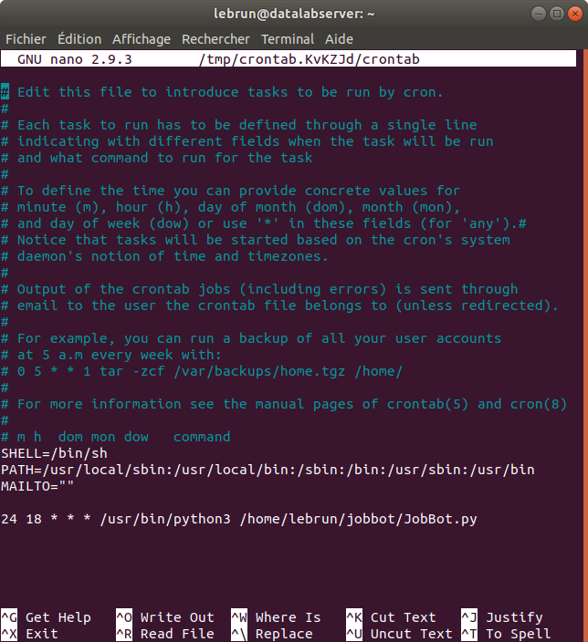

Répertoire de destination des fichiers CSV de BackUP

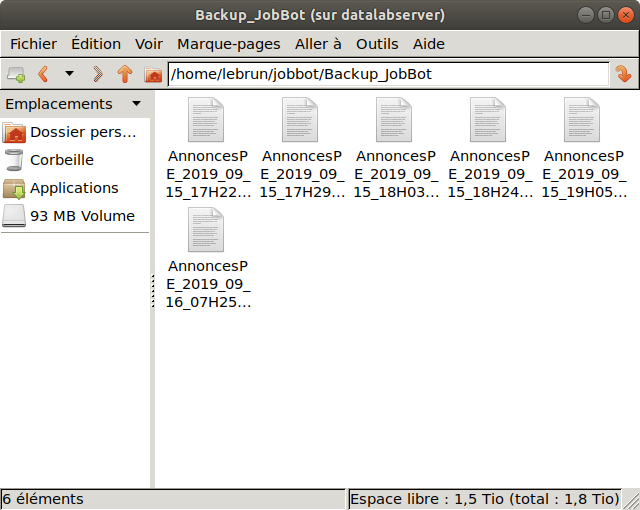

## GitHub

[figure not shown]

Branches

[figure not shown]